# R Notebook

Jared Sullin

## https://www.kaggle.com/rankirsh/esports-earnings/notebooks

```r
EsportsEarnings <- read.csv("GeneralEsportData.csv")
EsportsEarnings
```

| Game | ReleaseDate | Genre | TotalEarnings | OnlineEarnings | TotalPlayers | TotalTournaments |
| --- | --- | --- | --- | --- | --- | --- |
| Age of Empires | 1997 | Strategy | 190075.61 | 33235.72 | 246 | 95 |
| Age of Empires II | 1999 | Strategy | 1629065.26 | 1011400.39 | 1064 | 663 |
| Age of Empires III | 2005 | Strategy | 68113.85 | 26613.85 | 106 | 76 |
| Age of Empires Online | 2011 | Strategy | 3294.56 | 3294.56 | 16 | 8 |
| Age of Mythology | 2002 | Strategy | 52360.00 | 360.00 | 22 | 6 |
| Among Us | 2018 | Strategy | 66000.00 | 66000.00 | 10 | 6 |
| Auto Chess | 2019 | Strategy | 1076322.28 | 40800.00 | 72 | 6 |
| Brawl Stars | 2018 | Strategy | 94950.00 | 8700.00 | 51 | 10 |
| Chess.com | 2007 | Strategy | 1060988.94 | 1060988.94 | 630 | 183 |
| chess24 | 2014 | Strategy | 1184696.09 | 1184696.09 | 61 | 10 |

[output cut: 502 more lines]

```r
NA
```

## Histogram 1

1. what is the total number of Total Tournaments thought the years

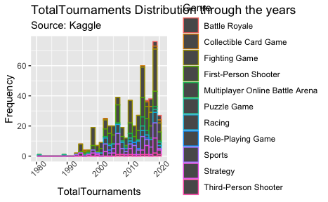

```r
ggplot( EsportsEarnings, aes(x=  ReleaseDate, fill =TotalTournaments, color = Genre))+
  geom_histogram()+
  theme(, axis.text.x = element_text(angle = 45))+
   labs(title = "TotalTournaments Distribution through the years",
       subtitle = "Source: Kaggle",
       x = "TotalTournaments",
       y= "Frequency" )
```

```r
median(EsportsEarnings$TotalTournaments)
```

[output not shown]

```r
mean(EsportsEarnings$TotalTournaments)
```

[output not shown]

```r
sd(EsportsEarnings$TotalTournaments)
```

[output not shown]

```r
 a <- EsportsEarnings$TotalTournaments

  max(a) - min(a)
```

[output not shown]

#Mean: 82.22461

#Median: 5

#Standard Deviation: 420.0819

#Range: 6061

#Skew: Right

## Histogram 2

2. What annual amount is most common for Esports Players to earn?

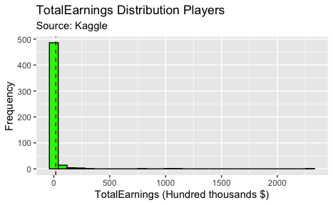

```r
ggplot(data = EsportsEarnings, mapping = aes(x = TotalEarnings
/100000)) +
  geom_histogram(color = "black", fill = "Green", show.legend = FALSE) +
  geom_vline(aes(xintercept = mean(TotalEarnings
/100000)), color = "red4", linetype = "dashed") +
  labs(title = "TotalEarnings Distribution Players",
       subtitle = "Source: Kaggle",
       x = "TotalEarnings (Hundred thousands $)",
       y= "Frequency")
```

as we can see from the graph it is either that the total earnings are fairly low for Esports players and do not usually make over one hundred thousand dollars. and the median price range is 37952.83 dollars and eighty three cents.

```r
median(EsportsEarnings$TotalEarnings)
```

```
[1] 37952.83
```

```r
mean(EsportsEarnings$TotalEarnings)
```

```
[1] 1781337
```

```r
sd(EsportsEarnings$TotalEarnings)
```

```
[1] 12816626
```

```r
 a <- EsportsEarnings$TotalEarnings

  max(a) - min(a)
```

```
[1] 229321217
```

#Mean: 1781337

#Median: 37952.83

#Standard Deviation: 12816626

#Range: 229321217

## Histogram 3

3. What is Online Earnings Distribution Players thought the years

```r
bg<- ggplot(EsportsEarnings, aes(x= Genre, y =  OnlineEarnings, fill = Genre))+
  theme(legend.position = "none", axis.text.x = element_text(angle = 90, vjust = 1, hjust=1))+
  geom_col(stat = "count")+
  labs(y= "OnlineEarnings (in Millions)", title = "Online Earnings per Genre", subtitle = "1980 - 2020")
```

```
Ignoring unknown parameters: stat
```

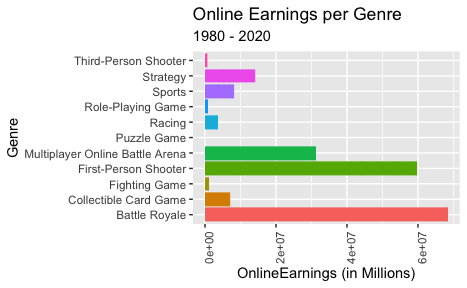

```r
bg + coord_flip()
```

as we can see battle royales make the most thought the years or mabey because there was a big boom of them in the past ten years and is very profitable.

```r
median(EsportsEarnings$OnlineEarnings)
```

```
[1] 20
```

```r
mean(EsportsEarnings$OnlineEarnings)
```

```
[1] 380569.7
```

```r
sd(EsportsEarnings$OnlineEarnings)
```

```
[1] 3076339
```

```r
 z<- EsportsEarnings$OnlineEarnings

  max(z) - min(z)
```

```
[1] 57238295
```

#Mean: 380569.7

#Median: 20

#Standard Deviation: 3076339

#Range: 57238295

#Skew: Right

## Histogram 4

4. what are genre are most players playing thought the years

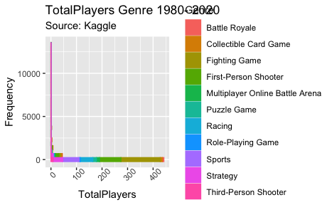

```r
ggplot( EsportsEarnings, aes(y =TotalPlayers, fill =Genre, color = Genre))+
  geom_histogram()+
  theme(, axis.text.x = element_text(angle = 45))+
   labs(title = "TotalPlayers Genre 1980- 2020",
       subtitle = "Source: Kaggle",
       x = "TotalPlayers",
       y= "Frequency" )
```

```r
median(EsportsEarnings$TotalPlayers)
```

```
[1] 20.5
```

```r
mean(EsportsEarnings$TotalPlayers)
```

```
[1] 190.2852
```

```r
sd(EsportsEarnings$TotalPlayers)
```

```
[1] 807.4907
```

```r
 z<- EsportsEarnings$TotalPlayers

  max(z) - min(z)
```

```
[1] 13358
```

#Mean: 190.2852

#Median: 20.5

#Standard Deviation: 807.4907

#Range: 13358